# Taller de Analisis de datos con IRT

Francisco Meneses Rivas - CIAE

2026-03-12

# Preparación de datos

```r
# cargar paquetes

if (!require("pacman")) install.packages("pacman")
pacman::p_load(dplyr, haven,lavaan)
```

```r
injuv_2025 <- read_dta("input/Base Final 2025 2.dta")

# Seleccionamos variables de interes

injuv_2025_vp  = injuv_2025 %>%
  select(
    starts_with("m8_p88"),
    m8_p87_1,


) %>%
  na.omit()

# Ajustamos para que 1 (si) sea 1 y 2 (no) sea 0


injuv_2025_vp = injuv_2025_vp %>%
  mutate_all(.,~ifelse(.==2,0,1) %>% as.factor() )
```

```r
summary(injuv_2025_vp)
```

```
##  m8_p88_1 m8_p88_2 m8_p88_3 m8_p88_4 m8_p88_5 m8_p88_6 m8_p88_7 m8_p87_1
##  0:4069   0:4344   0:4251   0:4288   0:4265   0:4275   0:4530   0:1762
##  1: 551   1: 276   1: 369   1: 332   1: 355   1: 345   1:  90   1:2858
```

# Modelamiento y calculo

En general, modelamos de la siguiente manera

’ variable_latente_n1 =~ var1 + var2 + var3 variable_latente_n2 =~ var4 + var5 + var6

’

Donde cada variable latente es medida por (=~) por un conjunto de variables observadas.

> Ejercicio
- Dibuja un modelo con una, dos o tres dimensiones. Puedes no usar todos los items. Lo que te haga más sentido
- Pasa el modelo a codigo
- Pre-registra el resultado en la hoja de calculo compartida
  - https://docs.google.com/spreadsheets/d/1jjOshn7yQbqjdk2EHY8K2uh810KsdcIshpJjK5PIODs/edit?gid=0#gid=0
- Evalua el ajuste
- Registra resultados

```r
modelo_afc_vp = ' violencia_pareja_controladora =~   m8_p88_1 +  m8_p88_5 + m8_p88_6 + m8_p88_4
   violencia_pareja_maltrato=~ m8_p88_3  + m8_p88_2 +  m8_p88_7

'


 ajuste_modelo_vp = lavaan::cfa(modelo_afc_vp,
            estimator = "WLSMV",
            ordered = c(
  "m8_p88_1",
  "m8_p88_2",
  "m8_p88_3",
  "m8_p88_4",
  "m8_p88_5",
  "m8_p88_6",
  "m8_p88_7"
),

data= injuv_2025_vp
)
```

# Evaluación del ajuste

Para evaluar el ajuste observamos:

- Indicadores de ajuste - RMSE debe ser menor a 0.08, idealmente menor a 0.05. Quizas menor a 0.1 - SRMR debe ser menor a 0.08, idealmente menor a 0.3 - CFI/TLI debe ser mayor a 0.9, ojala > 0.95 - p de Chi2 debe no ser significativo
- Cargas factoriales
  - minimo 0.4
  - idealmente 0.7
- Verificar que no existen “warnings”

```r
summary(ajuste_modelo_vp,
            fit.measures = TRUE,
            standardized=T,
            rsquare=T
        )
```

```
## lavaan 0.6-18 ended normally after 24 iterations
##
##   Estimator                                       DWLS
##   Optimization method                           NLMINB
##   Number of model parameters                        15
##
##   Number of observations                          4620
##
## Model Test User Model:
##                                               Standard      Scaled
##   Test Statistic                                33.177      52.411
##   Degrees of freedom                                13          13
##   P-value (Chi-square)                           0.002       0.000
##   Scaling correction factor                                  0.638
##   Shift parameter                                            0.411
##     simple second-order correction
##
## Model Test Baseline Model:
##
##   Test statistic                              6809.986    5178.802
##   Degrees of freedom                                21          21
##   P-value                                        0.000       0.000
##   Scaling correction factor                                  1.316
##
## User Model versus Baseline Model:
##
##   Comparative Fit Index (CFI)                    0.997       0.992
##   Tucker-Lewis Index (TLI)                       0.995       0.988
##
##   Robust Comparative Fit Index (CFI)                         0.973
##   Robust Tucker-Lewis Index (TLI)                            0.957
##
## Root Mean Square Error of Approximation:
##
##   RMSEA                                          0.018       0.026
##   90 Percent confidence interval - lower         0.011       0.019
##   90 Percent confidence interval - upper         0.026       0.033
##   P-value H_0: RMSEA <= 0.050                    1.000       1.000
##   P-value H_0: RMSEA >= 0.080                    0.000       0.000
##
```

[output cut: 63 more lines]

```
##    .m8_p88_3          0.297                               0.297    0.297
##    .m8_p88_2          0.293                               0.293    0.293
##    .m8_p88_7          0.526                               0.526    0.526
##     vlnc_prj_cntrl    0.518    0.032   16.368    0.000    1.000    1.000
##     vlnc_prj_mltrt    0.703    0.035   19.882    0.000    1.000    1.000
##
## R-Square:
##                    Estimate
##     m8_p88_1          0.518
##     m8_p88_5          0.475
##     m8_p88_6          0.615
##     m8_p88_4          0.812
##     m8_p88_3          0.703
##     m8_p88_2          0.707
##     m8_p88_7          0.474
```

Hacemos una tabla resumida del ajuste

```r
tabla_ajuste <- data.frame(
  Indicadores = fitMeasures(
    ajuste_modelo_vp,
    c("chisq","df","pvalue",
      "cfi","tli",
      "rmsea","rmsea.ci.lower","rmsea.ci.upper",
      "srmr")
  )
)

tabla_ajuste %>% kableExtra::kbl()
```

|  | Indicadores |
| --- | --- |
| chisq | 33.177431119 |
| df | 13.000000000 |
| pvalue | 0.001602535 |
| cfi | 0.997027917 |
| tli | 0.995198943 |
| rmsea | 0.018331047 |
| rmsea.ci.lower | 0.010703341 |
| rmsea.ci.upper | 0.026175079 |
| srmr | 0.033878072 |

```r
#Evaluar asociación entre factores
lavInspect(ajuste_modelo_vp, "cor.lv")
```

```
##                               vlnc_prj_c vlnc_prj_m
## violencia_pareja_controladora      1.000
## violencia_pareja_maltrato          0.868      1.000
```

Con esto podemos mirar opciones de mejora

```r
lavaan::modificationindices(ajuste_modelo_vp)
```

```
##                              lhs op      rhs     mi    epc sepc.lv sepc.all
## 41 violencia_pareja_controladora =~ m8_p88_3  0.829  0.384   0.277    0.277
## 42 violencia_pareja_controladora =~ m8_p88_2  0.847 -0.362  -0.261   -0.261
## 43 violencia_pareja_controladora =~ m8_p88_7  0.005  0.020   0.015    0.015
## 44     violencia_pareja_maltrato =~ m8_p88_1  1.318  0.208   0.174    0.174
## 45     violencia_pareja_maltrato =~ m8_p88_5  1.664  0.245   0.206    0.206
## 46     violencia_pareja_maltrato =~ m8_p88_6  1.414 -0.229  -0.192   -0.192
## 47     violencia_pareja_maltrato =~ m8_p88_4  1.066 -0.218  -0.183   -0.183
## 48                      m8_p88_1 ~~ m8_p88_5 25.423 -0.178  -0.178   -0.353
## 49                      m8_p88_1 ~~ m8_p88_6  2.973  0.067   0.067    0.155
## 50                      m8_p88_1 ~~ m8_p88_4  2.614  0.064   0.064    0.212
## 51                      m8_p88_1 ~~ m8_p88_3  3.327  0.071   0.071    0.188
## 52                      m8_p88_1 ~~ m8_p88_2  0.128 -0.014  -0.014   -0.038
## 53                      m8_p88_1 ~~ m8_p88_7  0.004 -0.004  -0.004   -0.007
## 54                      m8_p88_5 ~~ m8_p88_6  4.557  0.090   0.090    0.201
```

[output cut: 43 more lines]

# Reporte

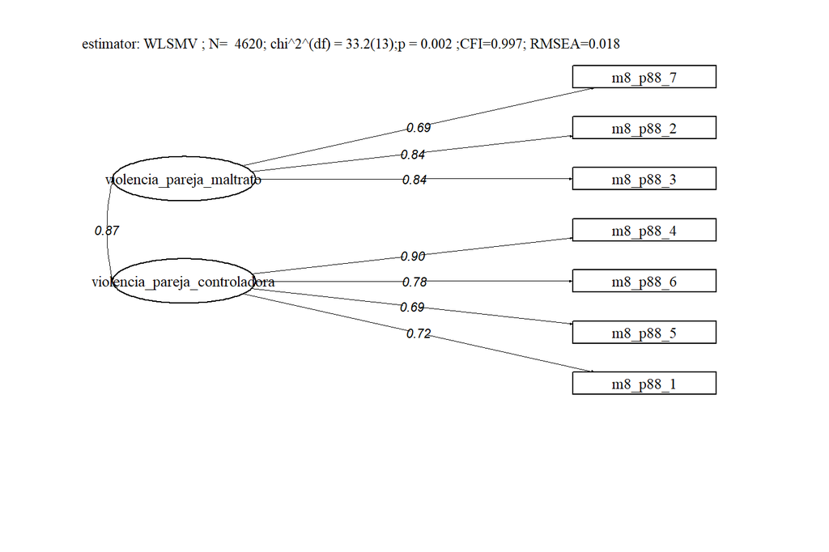

# Otras alternativas de modelo a testear

modelo_afc_vp = ’ violencia_pareja_controladora =~ m8_p88_1 + m8_p88_5 + m8_p88_6 + m8_p88_4 violencia_pareja_maltrato=~ m8_p88_3 + m8_p88_2 + m8_p88_7

’ modelo_afc_vp = ’ violencia_pareja_controladora =~ m8_p88_1 + m8_p88_6 + m8_p88_4 violencia_pareja_psicologica =~ m8_p88_3 + m8_p88_5 violencia_pareja_fisicosexual =~ m8_p88_2 + m8_p88_7 ’